# R Notebook

# 兩個因子變數，一個數值變數的點條圖

# 注意jitter=T是為了避免於同處過度繪製(overplotting)!

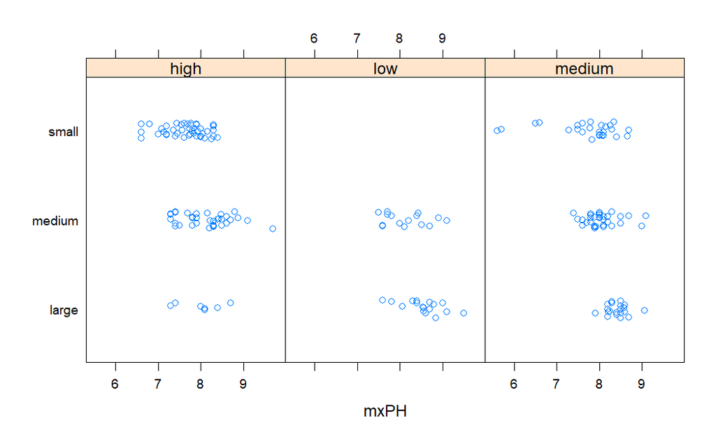

```r
stripplot(size ~ mxPH | speed, data = algae, jitter = T)
```

## 2.2 資料摘要與彙總

## 2.2.1 摘要統計量

```r
library(ascentTraining)
dow_jones_data
```

| Date | DJI.Open | DJI.High | DJI.Low | DJI.Close | DJI.Volume | DJI.Adj.Close |
| --- | --- | --- | --- | --- | --- | --- |
| 12/31/2014 | 17987.66 | 18043.22 | 17820.88 | 17823.07 | 82840000 | 17823.07 |
| 12/30/2014 | 18035.02 | 18035.02 | 17959.70 | 17983.07 | 47490000 | 17983.07 |
| 12/29/2014 | 18046.58 | 18073.04 | 18021.57 | 18038.23 | 53870000 | 18038.23 |
| 12/26/2014 | 18038.30 | 18103.45 | 18038.30 | 18053.71 | 52570000 | 18053.71 |
| 12/24/2014 | 18035.73 | 18086.24 | 18027.78 | 18030.21 | 42870000 | 18030.21 |
| 12/23/2014 | 17971.51 | 18069.22 | 17970.16 | 18024.17 | 82890000 | 18024.17 |
| 12/22/2014 | 17812.25 | 17962.78 | 17812.25 | 17959.44 | 98460000 | 17959.44 |
| 12/19/2014 | 17778.02 | 17874.03 | 17746.55 | 17804.80 | 343690000 | 17804.80 |
| 12/18/2014 | 17367.85 | 17778.40 | 17367.85 | 17778.15 | 123940000 | 17778.15 |
| 12/17/2014 | 17069.16 | 17389.30 | 17069.16 | 17356.87 | 118220000 | 17356.87 |

[output cut: 242 more lines]

```r
str(dow_jones_data)
```

```
'data.frame':   252 obs. of  7 variables:
 $ Date         : Factor w/ 252 levels "01/02/2014","01/03/2014",..: 252 251 250 249 248 247 246 245 244 243 ...
 $ DJI.Open     : num  17988 18035 18047 18038 18036 ...
 $ DJI.High     : num  18043 18035 18073 18103 18086 ...
 $ DJI.Low      : num  17821 17960 18022 18038 18028 ...
 $ DJI.Close    : num  17823 17983 18038 18054 18030 ...
 $ DJI.Volume   : num  82840000 47490000 53870000 52570000 42870000 ...
 $ DJI.Adj.Close: num  17823 17983 18038 18054 18030 ...
```

```r
mean(dow_jones_data$DJI.Open)
```

```
[1] 16772.84
```

```r
# dow30 <- read.
```

```r
# 截尾平均數
mean(dow_jones_data$DJI.Open, trim = 0.1)
```

```
[1] 16748
```

```r
## ----warning=FALSE, message=FALSE----------------------------------------
library(DMwR2)
data(algae)
```

# 自訂函數 Mode 的解釋

- unique(x)：提取向量 x 中的唯一值。
- match(x, ux)：返回 x 中每個元素在 ux 中的位置。
- tabulate(match(x, ux))：計算每個位置的頻率（即每個唯一值在 x 中出現的次數）。
- which.max(…)：找到頻率最高的位置。
- ux[which.max(…)]：返回頻率最高的唯一值，這就是眾數。

```r
# 自訂眾數計算函數
Mode <- function(x) {
  ux <- unique(x)
  ux[which.max(tabulate(match(x, ux)))]
}

Mode(algae$size)
```

```
[1] medium
Levels: large medium small
```

```r
# 以次數分佈表核驗Mode函數計算結果
table(algae$size)
```

```
 large medium  small
    45     84     71
```

```r
unique(algae$size)[which.max(tabulate(match(algae$size, unique(algae$size))))] # 如何逐步理解程式碼
```

```
[1] medium
Levels: large medium small
```

```r
## ----warning = FALSE, message=FALSE--------------------------------------
mySamples <- c(19, 4, 5, 7, 29, 19, 29, 13, 25, 19) # c()想成combine!
# R語言單變量單峰資料眾數估計套件
library(modeest)
# 數值向量最常發生值估計法
mlv(mySamples, method = "mfv")
```

```
[1] 19
```

```r
# table(mySamples)
```

```r
## ------------------------------------------------------------------------
# 最常用的四分位數加上最小與最大值
quantile(dow_jones_data$DJI.Open, probs = c(0, 0.25, 0.5, 0.75, 1.0))
```

```
      0%      25%      50%      75%     100%
15372.93 16408.69 16716.93 17067.72 18046.58
```

```r
## ------------------------------------------------------------------------
# 結果與上面的四分位數有差異，其實quantile()函數有九種計算方法！
fivenum(dow_jones_data$DJI.Open)
```

```
[1] 15372.93 16408.47 16716.93 17068.20 18046.58
```

```r
## ------------------------------------------------------------------------
min(dow_jones_data$DJI.Open)
```

```
[1] 15372.93
```

```r
max(dow_jones_data$DJI.Open)
```

```
[1] 18046.58
```

# 一次傳回最小與最大值

```r
## ------------------------------------------------------------------------

range(dow_jones_data$DJI.Open)
```

```
[1] 15372.93 18046.58
```

# diff()常用於時間序列資料，依lag期數計算不同階數的差分值

```r
diff(range(dow_jones_data$DJI.Open)) # 後 - 前
```

```
[1] 2673.65
```

# 1到10跨兩期的8個(Why?)差分值

手動計算過程，原始向量是 1:10： `1, 2, 3, 4, 5, 6, 7, 8, 9, 10`  
計算相隔 2 個位置的元素之間的差值：  
`(3 - 1), (4 - 2), (5 - 3), (6 - 4), (7 - 5), (8 - 6), (9 - 7), (10 - 8)`  
這些計算結果是：  
2, 2, 2, 2, 2, 2, 2, 2

```r
diff(1:10, lag = 2)
```

```
[1] 2 2 2 2 2 2 2 2
```

這表明對於 1:10 這個序列，任意相隔 2 個位置的元素之間的差值都是相同的，即 2。

# R語言函數的引數可以偷懶只寫前幾個字母，只要能區辨即可

```r
diff(1:10, lag = 2, diff = 2) # 跨兩期，差分運算兩次
```

```
[1] 0 0 0 0 0 0
```

```r
## ------------------------------------------------------------------------
IQR(dow_jones_data$DJI.Open)
```

```
[1] 659.0254
```

```r
## ------------------------------------------------------------------------
var(dow_jones_data$DJI.Open) # 原始單位的平方
```

```
[1] 301295.5
```

# 與原始單位一致

```r
sd(dow_jones_data$DJI.Open)
```

```
[1] 548.9039
```

# 直接由標準差與平均數計算變異係數

```r
sd(dow_jones_data$DJI.Open)/mean(dow_jones_data$DJI.Open)
```

```
[1] 0.03272576
```

# R語言地理資料分析與建模套件{raster}

```r
library(raster)
```

```r
## ------------------------------------------------------------------------
# 光柵(raster)資料常須計算變異係數
cv(1:10)
```

```
[1] 55.04819
```

```r
sd(1:10)/mean(1:10)
```

```
[1] 0.5504819
```

```r
# cv(dow30$Open) # cv*100
## ------------------------------------------------------------------------
# R核心開發團隊維護套件{stats}中的mad()
mad(dow_jones_data$DJI.Open) # mad: median absolute deviation 中位數絕對離差
```

```
[1] 504.2259
```

```r
## ----warning=FALSE, message=FALSE----------------------------------------
# 衡量所得不均、集結度與貧困的R套件
library(ineq)
# 建立所得向量x
x <- c(541, 1463, 2445, 3438, 4437, 5401, 6392, 8304,
11904, 22261)
```

```r
# 吉尼集中度計算函數
ineq(x)
```

```
[1] 0.4620911
```

```r
## ------------------------------------------------------------------------
# 自定義吉尼不純度函數
Gini <- function(x) {
  # 合理性檢查
  if (!is.factor(x)) {
    return("Please input factor variable.")
  } else {
    1 - sum((table(x)/sum(table(x)))^2) # (2.1)式
  }
}
```

# 完美同質情況

```r
as.factor(rep("a", 6)) # "a"重複6次
```

```
[1] a a a a a a
Levels: a
```

```r
Gini(as.factor(rep("a", 6)))
```

```
[1] 0
```

# 非完美情況

```r
## ------------------------------------------------------------------------
as.factor(c(rep("a", 1), rep("b", 5)))
```

```
[1] a b b b b b
Levels: a b
```

```r
Gini(as.factor(c(rep("a", 1), rep("b", 5))))
```

```
[1] 0.2777778
```

```r
Gini(as.factor(c(rep("a", 1), rep("b", 5))))
```

```
[1] 0.2777778
```

# 完美異質情況

```r
as.factor(c("a", "b", "c", "d", "e"))
```

```
[1] a b c d e
Levels: a b c d e
```

```r
Gini(as.factor(c("a", "b", "c", "d", "e"))) # 1 - 1/k = 1 - 1/5 = 0.8
```

```
[1] 0.8
```

```r
Gini(as.factor(c("c", "b", "c", "c", "e")))
```

```
[1] 0.56
```

## 2.2.2 R語言群組與摘要 ————————————————————————

# 知名的鳶尾花資料集

```r
head(iris, 3)
```

|  | Sepal.Length | Sepal.Width | Petal.Length | Petal.Width | Species |
| --- | --- | --- | --- | --- | --- |
| 1 | 5.1 | 3.5 | 1.4 | 0.2 | setosa |
| 2 | 4.9 | 3.0 | 1.4 | 0.2 | setosa |
| 3 | 4.7 | 3.2 | 1.3 | 0.2 | setosa |

```r
str(iris)
```

```
'data.frame':   150 obs. of  5 variables:
 $ Sepal.Length: num  5.1 4.9 4.7 4.6 5 5.4 4.6 5 4.4 4.9 ...
 $ Sepal.Width : num  3.5 3 3.2 3.1 3.6 3.9 3.4 3.4 2.9 3.1 ...
 $ Petal.Length: num  1.4 1.4 1.3 1.5 1.4 1.7 1.4 1.5 1.4 1.5 ...
 $ Petal.Width : num  0.2 0.2 0.2 0.2 0.2 0.4 0.3 0.2 0.2 0.1 ...
 $ Species     : Factor w/ 3 levels "setosa","versicolor",..: 1 1 1 1 1 1 1 1 1 1 ...
```

## ————————————————————————

# 量綱接近，花瓣寬度數值最小

```r
summary(iris)
```

```
  Sepal.Length    Sepal.Width     Petal.Length    Petal.Width          Species
 Min.   :4.300   Min.   :2.000   Min.   :1.000   Min.   :0.100   setosa    :50
 1st Qu.:5.100   1st Qu.:2.800   1st Qu.:1.600   1st Qu.:0.300   versicolor:50
 Median :5.800   Median :3.000   Median :4.350   Median :1.300   virginica :50
 Mean   :5.843   Mean   :3.057   Mean   :3.758   Mean   :1.199
 3rd Qu.:6.400   3rd Qu.:3.300   3rd Qu.:5.100   3rd Qu.:1.800
 Max.   :7.900   Max.   :4.400   Max.   :6.900   Max.   :2.500
```

```r
## ------------------------------------------------------------------------
# subset()選取各花種子集用法
library(psych )
setosa <- subset(iris, Species == 'setosa')
headtail(setosa)
```

|  | Sepal.Length | Sepal.Width | Petal.Length | Petal.Width | Species |
| --- | --- | --- | --- | --- | --- |
| 1 | 5.1 | 3.5 | 1.4 | 0.2 | setosa |
| 2 | 4.9 | 3 | 1.4 | 0.2 | setosa |
| 3 | 4.7 | 3.2 | 1.3 | 0.2 | setosa |
| 4 | 4.6 | 3.1 | 1.5 | 0.2 | setosa |
| ... | ... | ... | ... | ... | NA |
| 47 | 5.1 | 3.8 | 1.6 | 0.2 | setosa |
| 48 | 4.6 | 3.2 | 1.4 | 0.2 | setosa |
| 49 | 5.3 | 3.7 | 1.5 | 0.2 | setosa |
| 50 | 5 | 3.3 | 1.4 | 0.2 | setosa |

# 逐步收納結果用(for gathering results)

```r
results <- data.frame()
```

# 留意因子變數unique()後的結果

```r
for (species in unique(iris$Species)) {
  # 逐花種取子集
  tmp <- subset(iris, Species == species)
  # 開始摘要統計
  count <- nrow(tmp)
  mean <- mean(tmp$Sepal.Length)
  median <- median(tmp$Sepal.Length)
  # 結果封裝成資料框後再合併
  results <- rbind(results, data.frame(species, count, mean,
  median))
}
results
```

| species | count | mean | median |
| --- | --- | --- | --- |
| setosa | 50 | 5.006 | 5.0 |
| versicolor | 50 | 5.936 | 5.9 |
| virginica | 50 | 6.588 | 6.5 |

# 群組與摘要apply()系列函數

```r
## ------------------------------------------------------------------------

tapply(iris$Sepal.Length, iris$Species, FUN = length)
```

```
    setosa versicolor  virginica
        50         50         50
```

# FUN中設定的摘要統計計算函數，也可以用匿名函數定義多個函數

# 匿名函數的參數u代表分組數據

```r
tapply(iris$Sepal.Length, iris$Species, FUN = function(u)
{c(count = length(u), mean = mean(u), median = median(u))})
```

```
$setosa
 count   mean median
50.000  5.006  5.000

$versicolor
 count   mean median
50.000  5.936  5.900

$virginica
 count   mean median
50.000  6.588  6.500
```

# 限定環境與結合模型公式符號的aggregate()

```r
aggregate(Sepal.Length ~ Species, data = iris,
FUN = 'length')
```

| Species | Sepal.Length |
| --- | --- |
| setosa | 50 |
| versicolor | 50 |
| virginica | 50 |

# 匿名函數用法同tapply()，但傳回結果為data.frame非list

```r
aggregate(Sepal.Length ~ Species, data = iris, FUN =
function(u) {c(count = length(u), mean = mean(u),
median = median(u))})
```

[output not shown]

# 載入R語言知名圖形文法繪圖套件{ggplot2}

```r
## ----warning=FALSE, message=FALSE----------------------------------------

library(ggplot2)
# 讀取套件{ggplot2}中的鑽石資料集
data(diamonds)
```

# 物件類別為”tbl_df”

```r
class(diamonds)
```

```
[1] "tbl_df"     "tbl"        "data.frame"
```

```r
head(diamonds)
```

| carat | cut | color | clarity | depth | table | price | x | y | z |
| --- | --- | --- | --- | --- | --- | --- | --- | --- | --- |
| 0.23 | Ideal | E | SI2 | 61.5 | 55 | 326 | 3.95 | 3.98 | 2.43 |
| 0.21 | Premium | E | SI1 | 59.8 | 61 | 326 | 3.89 | 3.84 | 2.31 |
| 0.23 | Good | E | VS1 | 56.9 | 65 | 327 | 4.05 | 4.07 | 2.31 |
| 0.29 | Premium | I | VS2 | 62.4 | 58 | 334 | 4.20 | 4.23 | 2.63 |
| 0.31 | Good | J | SI2 | 63.3 | 58 | 335 | 4.34 | 4.35 | 2.75 |
| 0.24 | Very Good | J | VVS2 | 62.8 | 57 | 336 | 3.94 | 3.96 | 2.48 |

## # 注意cut與color的水準數

```r
## ----eval=FALSE----------------------------------------------------------
 str(diamonds)
```

```
tibble [53,940 × 10] (S3: tbl_df/tbl/data.frame)
 $ carat  : num [1:53940] 0.23 0.21 0.23 0.29 0.31 0.24 0.24 0.26 0.22 0.23 ...
 $ cut    : Ord.factor w/ 5 levels "Fair"<"Good"<..: 5 4 2 4 2 3 3 3 1 3 ...
 $ color  : Ord.factor w/ 7 levels "D"<"E"<"F"<"G"<..: 2 2 2 6 7 7 6 5 2 5 ...
 $ clarity: Ord.factor w/ 8 levels "I1"<"SI2"<"SI1"<..: 2 3 5 4 2 6 7 3 4 5 ...
 $ depth  : num [1:53940] 61.5 59.8 56.9 62.4 63.3 62.8 62.3 61.9 65.1 59.4 ...
 $ table  : num [1:53940] 55 61 65 58 58 57 57 55 61 61 ...
 $ price  : int [1:53940] 326 326 327 334 335 336 336 337 337 338 ...
 $ x      : num [1:53940] 3.95 3.89 4.05 4.2 4.34 3.94 3.95 4.07 3.87 4 ...
 $ y      : num [1:53940] 3.98 3.84 4.07 4.23 4.35 3.96 3.98 4.11 3.78 4.05 ...
 $ z      : num [1:53940] 2.43 2.31 2.31 2.63 2.75 2.48 2.47 2.53 2.49 2.39 ...
```

```r
## ----warning=FALSE, message=FALSE----------------------------------------
library(UsingR)
# 以模型公式符號的加號運算子串起兩個因子變數
headtail(aggregate(price ~ cut + color, data = diamonds,
FUN = "mean"))
```

| cut | color | price |
| --- | --- | --- |
| Fair | D | 4291.061 |
| Good | D | 3405.382 |
| Very Good | D | 3470.467 |
| Premium | D | 3631.293 |
| Ideal | D | 2629.095 |
| Fair | E | 3682.312 |
| Good | E | 3423.644 |
| Very Good | E | 3214.652 |
| Premium | E | 3538.914 |
| Ideal | E | 2597.550 |

[output cut: 25 more lines]

[output not shown]

# 以cbind()組織所有待分組變數

```r
headtail(aggregate(cbind(price, carat) ~ cut + color,
data = diamonds, "mean"))
```

| cut | color | price | carat |
| --- | --- | --- | --- |
| Fair | D | 4291.061 | 0.9201227 |
| Good | D | 3405.382 | 0.7445166 |
| Very Good | D | 3470.467 | 0.6964243 |
| Premium | D | 3631.293 | 0.7215471 |
| Ideal | D | 2629.095 | 0.5657657 |
| Fair | E | 3682.312 | 0.8566071 |
| Good | E | 3423.644 | 0.7451340 |
| Very Good | E | 3214.652 | 0.6763167 |
| Premium | E | 3538.914 | 0.7177450 |
| Ideal | E | 2597.550 | 0.5784012 |

[output cut: 25 more lines]

[output not shown]

# 欲群組摘要的變數也可以是因子變數

```r
headtail(aggregate(clarity ~ cut + color, data = diamonds,
"table"))
```

[output not shown]

[output cut: 25 more lines]

[output not shown]

```r
# clarity因子變數的各個水準名稱
levels(diamonds$clarity)
```

```
[1] "I1"   "SI2"  "SI1"  "VS2"  "VS1"  "VVS2" "VVS1" "IF"
```

```r
## ----warning=FALSE, message=FALSE----------------------------------------
library(doBy)
# 輸出格式與aggregate()相同
summaryBy(Sepal.Length ~ Species, data = iris, FUN =
function(x) {c(count = length(x), mean = mean(x), median =
median(x))})
```

|  | Species | Sepal.Length.count | Sepal.Length.mean | Sepal.Length.median |
| --- | --- | --- | --- | --- |
| 1 | setosa | 50 | 5.006 | 5.0 |
| 2 | versicolor | 50 | 5.936 | 5.9 |
| 3 | virginica | 50 | 6.588 | 6.5 |

```r
## ----warning=FALSE, message=FALSE----------------------------------------
library(plyr)
# 留意傳入colMeans()的資料子集x為何要移除第五欄
ddply(iris, 'Species', function(x) c(count = nrow(x), mean
= colMeans(x[-5])))
```

| Species | count | mean.Sepal.Length | mean.Sepal.Width | mean.Petal.Length | mean.Petal.Width |
| --- | --- | --- | --- | --- | --- |
| setosa | 50 | 5.006 | 3.428 | 1.462 | 0.246 |
| versicolor | 50 | 5.936 | 2.770 | 4.260 | 1.326 |
| virginica | 50 | 6.588 | 2.974 | 5.552 | 2.026 |

```r
## ----warning=FALSE, message=FALSE----------------------------------------
# R語言data.frame的延伸套件
library(data.table)
iris.tbl <- data.table(iris)
# 前者(data.table)繼承自後者(data.frame)
class(iris.tbl)
```

```
[1] "data.table" "data.frame"
```

```r
# list()串接多個變數進行取值，顯示方式自動取頭尾
iris.tbl[ , list(Sepal.Length, Species)]
```

| Sepal.Length | Species |
| --- | --- |
| 5.1 | setosa |
| 4.9 | setosa |
| 4.7 | setosa |
| 4.6 | setosa |
| 5.0 | setosa |
| 5.4 | setosa |
| 4.6 | setosa |
| 5.0 | setosa |
| 4.4 | setosa |
| 4.9 | setosa |

[output cut: 140 more lines]

```r
# data.table橫列邏輯值取值
iris.tbl[iris.tbl$Petal.Width <= 0.1,]
```

| Sepal.Length | Sepal.Width | Petal.Length | Petal.Width | Species |
| --- | --- | --- | --- | --- |
| 4.9 | 3.1 | 1.5 | 0.1 | setosa |
| 4.8 | 3.0 | 1.4 | 0.1 | setosa |
| 4.3 | 3.0 | 1.1 | 0.1 | setosa |
| 5.2 | 4.1 | 1.5 | 0.1 | setosa |
| 4.9 | 3.6 | 1.4 | 0.1 | setosa |

```r
# data.table移除變數是令其為NULL
iris.tbl[ , Sepal.Width := NULL]; iris.tbl
```

| Sepal.Length | Petal.Length | Petal.Width | Species |
| --- | --- | --- | --- |
| 5.1 | 1.4 | 0.2 | setosa |
| 4.9 | 1.4 | 0.2 | setosa |
| 4.7 | 1.3 | 0.2 | setosa |
| 4.6 | 1.5 | 0.2 | setosa |
| 5.0 | 1.4 | 0.2 | setosa |
| 5.4 | 1.7 | 0.4 | setosa |
| 4.6 | 1.4 | 0.3 | setosa |
| 5.0 | 1.5 | 0.2 | setosa |
| 4.4 | 1.4 | 0.2 | setosa |
| 4.9 | 1.5 | 0.1 | setosa |

[output cut: 140 more lines]

```r
## ------------------------------------------------------------------------
# data.table群組與摘要語法特殊
iris.tbl[ , list(Sepal.Length = mean(Sepal.Length),
Petal.Width = median(Petal.Width)), by = Species]
```

| Species | Sepal.Length | Petal.Width |
| --- | --- | --- |
| setosa | 5.006 | 0.2 |
| versicolor | 5.936 | 1.3 |
| virginica | 6.588 | 2.0 |

## 2.3 屬性工程

## 2.3.1 屬性轉換與移除 ————————————————————————

# R語言產生隨機抽樣模擬數據

```r
set.seed(1234)
(X <- matrix(runif(12), 3))
```

```
          [,1]      [,2]        [,3]      [,4]
[1,] 0.1137034 0.6233794 0.009495756 0.5142511
[2,] 0.6222994 0.8609154 0.232550506 0.6935913
[3,] 0.6092747 0.6403106 0.666083758 0.5449748
```

# 橫向正規化(固定和)

```r
apply(X, 1, sum)
```

```
[1] 1.260830 2.409357 2.460644
```

```r
(X_sum100 <- X/apply(X, 1, sum)*100)
```

[output not shown]

```r
# 核驗結果
apply(X_sum100, 1, sum)
# 橫向正規化(固定最大值)
apply(X, 1, max)
(X_max100 <- X/apply(X, 1, max)*100)
# 核驗結果
apply(X_max100, 1, max)
# 橫向正規化(固定向量長)
sqrt(apply(X^2, 1, sum))
(X_length1 <- X/sqrt(apply(X^2, 1, sum)))
# 核驗結果
apply(X_length1^2, 1, sum)

## ------------------------------------------------------------------------
# 本節 running example
library(AppliedPredictiveModeling)
data(segmentationOriginal)
```

[output not shown]

```r
## ----eval=FALSE----------------------------------------------------------
## str(segmentationOriginal, list.len = 10)

## ----warning=FALSE, message=FALSE----------------------------------------
library(UsingR)
# 119個變數名稱，限於篇幅，只顯示頭尾
headtail(names(segmentationOriginal))
# 目標變數`Class`次數分佈`table`(segmentationOriginal$Case)
```

[output not shown]

```r
## ----eval=FALSE----------------------------------------------------------
## # 報表太大，請讀者自行執行
## summary(segmentationOriginal)

## ------------------------------------------------------------------------
# 自變項資料框傳入sapply()，以匿名函數計算各變數最小與最大值
headtail(sapply(segmentationOriginal[-(1:3)], function(u)
c(min = min(u), max = max(u))))

## ------------------------------------------------------------------------
# 因子屬性`Case`次數分佈`table`(segmentationOriginal$Case)
segTrain <- subset(segmentationOriginal, Case == "Train")
# table(segmentationOriginal$Case)
## ------------------------------------------------------------------------
# 類別標籤向量獨立為segTrainClass，1009個類別標籤值
segTrainClass <- segTrain$Class
length(segTrainClass)

## ------------------------------------------------------------------------
segTrainX <- segTrain[, -(1:3)]
# 1009個訓練樣本，116個屬性
dim(segTrainX)

## ----warning=FALSE, message=FALSE----------------------------------------
# 分類與迴歸訓練重要R套件
library(caret)
# 預設傳回近乎零變異的變數編號
nearZeroVar(segTrainX)
# ?nearZeroVar
# 近乎零變異變數名稱
names(segTrainX)[nearZeroVar(segTrainX)]
# 移除近乎零變異變數後存為segTrainXV
segTrainXV <- segTrainX[, -nearZeroVar(segTrainX)]
#table(segTrainX$MemberAvgAvgIntenStatusCh2)
## ------------------------------------------------------------------------
# 改變引數(saveMetrics)設定值，取得完整報表(報表很長，只檢視某些變數結果)
nearZeroVar(segTrainX, saveMetrics = TRUE)[68:75,]
# 輸出報表類別為資料框
class(nearZeroVar(segTrainX, saveMetrics = TRUE))
str(nearZeroVar(segTrainX, saveMetrics = TRUE))
# 零變異變數名稱
names(segTrainX)[nearZeroVar(segTrainX, saveMetrics =
TRUE)$zeroVar]

## ------------------------------------------------------------------------
# 擷取名稱帶有"Status"的變數編號
(statusColNum <- grep("Status", names(segTrainXV)))

## ------------------------------------------------------------------------
# 名稱有"Status"之變數成批產生次數分配表，確定均為三元以下變數
head(sapply(segTrainXV[, statusColNum], table))
# 分離出數值屬性矩陣segTrainXNC，NC表not categorical
segTrainXNC <- segTrainXV[, -statusColNum]

## ------------------------------------------------------------------------
# VarIntenCh3嚴重右偏
summary(segTrainXNC$VarIntenCh3)
max(segTrainX$VarIntenCh3)/min(segTrainX$VarIntenCh3)

## ----warning=FALSE, message=FALSE----------------------------------------
# 偏態係數計算
library(e1071)
skewness(segTrainXNC$VarIntenCh3)

## ----fig.align="center", fig.cap = "\\label{fig:VarIntenCh3_histden}肌動蛋白絲畫素強度標準差之直方圖與密度曲線"----
# 視覺化檢驗偏態狀況
hist(segTrainXNC$VarIntenCh3, prob = TRUE, ylim =
c(0, 0.009), xlab = 'VarIntenCh3')
lines(density(segTrainXNC$VarIntenCh3))
# 以位置量數細部查驗偏態狀況(注意66%與97%)
quantile(segTrainXNC$VarIntenCh3, probs = seq(0, 1, 0.01))

## ------------------------------------------------------------------------
# 以apply()+sort()計算並排序所有數值變數的偏態係數
skewValues <- apply(segTrainXNC, 2, skewness)
headtail(sort(skewValues, decreasing = TRUE))

## ----fig.align="center", fig.cap = "\\label{fig:rightskewed_hist}右偏前九高變數的直方圖", fig.height=8----
# 偏態係數高於3的變數
sort(skewValues[skewValues > 3], decreasing = TRUE)
# 取出右偏前九高的變數名稱
highlySkewed <- names(sort(skewValues, decreasing=TRUE))[1:9]
# 成批繪製直方圖
op <- par(mfrow = c(3,3))
invisible(lapply(highlySkewed, function(u)
{hist(segTrainXNC[[u]], main = paste("Histogram of ",
u), xlab = "", cex.main = 0.8)}))
par(op)

## ----echo=FALSE, fig.align="center", fig.cap = "\\label{fig:leftskewed_hist}左偏前九高變數的直方圖", fig.height=8----
symm <- names(sort(skewValues))[1:9]
op <- par(mfrow = c(3,3))
invisible(lapply(symm, function(u) {hist(segTrainXNC[[u]],
main = paste("Histogram of ", u),
xlab = "", cex.main = 0.8)}))
par(op)

## ----warning=FALSE, message=FALSE----------------------------------------
library(caret)
# BC轉換報表(lambda估計值為-0.9)
(Ch1AreaTrans <- BoxCoxTrans(segTrainXNC$AreaCh1))

## ------------------------------------------------------------------------
# 前六筆原始資料
head(segTrainXNC$AreaCh1)
# predict()泛型函數執行BC轉換計算
predict(Ch1AreaTrans, head(segTrainXNC$AreaCh1))
# 自撰BC公式驗證
(head(segTrainXNC$AreaCh1)^(-.9) - 1)/(-.9)

## 2.3.2 屬性萃取之主成份分析 ------------------------------------------------------------------------
# 資料標準化後進行PCA運算
pcaObject <- prcomp(segTrainXNC, center = TRUE, scale. = TRUE)

## ------------------------------------------------------------------------
# 檢視計算結果
names(pcaObject)

## ------------------------------------------------------------------------
# 驗證分數矩陣的計算
sum(scale(as.matrix(segTrainXNC)) %*% pcaObject$rotation ==
pcaObject$x)
# 分數矩陣中元素總數為樣本數乘上變數個數
1009*58

## ------------------------------------------------------------------------
# 各個主成份變異數占總變異數的比例逐漸遞減
(percentVariance <- pcaObject$sd^2/sum(pcaObject$sd^2)*100)

## ----fig.align="center", fig.cap = "\\label{fig:cell_screeplot}前25個主成份的陡坡圖"----
# 繪製陡坡圖
plot(percentVariance[1:25], xlab = "Principal Component",
ylab = "Proportion of Variance Explained ", type = 'b')

## ----fig.align="center", fig.cap = "\\label{fig:cell_cumvarplot}前25個主成份累積變異百分比折線圖"----
# 累積變異百分比折線圖
cumsum(percentVariance)
plot(cumsum(percentVariance)[1:25], xlab = "Principal
Component", ylab = "Cumulative Proportion of
Variance Explained", type = 'b')
abline(h = 0.9, lty = 2)

## ------------------------------------------------------------------------
# PCA座標轉換後的新座標值儲存在pcaObject中的元素x
head(pcaObject$x[, 1:5])

## ------------------------------------------------------------------------
# 檢視PCA前三個主成份與頭六個預測變數的負荷係數值
head(pcaObject$rotation[, 1:3])

## ------------------------------------------------------------------------
# preProcess()可以處理各種轉換，包括PCA
(segPP <- preProcess(segTrainXNC, method = c("BoxCox",
"center", "scale", "pca")))
# 物件類別為"preProcess"，通常與創建物件的函數同名
class(segPP)

## ------------------------------------------------------------------------
# 套用模型segPP對數值屬性矩陣做轉換
transformed <- predict(segPP, segTrainXNC)
# 原資料已降到19維的正交新空間中
str(transformed)
# 新空間前五個主成份下，前六筆樣本的座標值
head(transformed[, 1:5])
# predcit()方法轉換後輸出的物件類別為data.frame
class(transformed)


## 2.3.3 屬性挑選 ------------------------------------------------------------------------
# 58個數值變數的相關係數方陣
correlations <- cor(segTrainXNC)
dim(correlations)
correlations[1:4, 1:4]

## ----fig.align="center", fig.cap = "\\label{fig:cell_corrplot}相關係數矩陣視覺化圖形", warning=FALSE, message=FALSE, fig.height=6, fig.width=5----
# 載入R語言好用的相關係數方陣視覺化套件
library(corrplot)
corrplot(correlations, order = "hclust", tl.cex = 0.5)

# library(heatmaply)
# heatmaply_cor(correlations)

## ------------------------------------------------------------------------
# 傳回建議移除的變數編號
(highCorr <- findCorrelation(correlations, cutoff = .75))
# 原58個數值變數過濾掉32個剩下26個
filteredSegTrainXNC <- segTrainXNC[, -highCorr]
dim(filteredSegTrainXNC)

## ----warning=FALSE, message=FALSE----------------------------------------
# R語言屬性挑選套件
library(FSelector)
data(iris)
# 屬性訊息增益排名
(weights <- information.gain(Species~., data=iris))
(subset <- cutoff.k(weights, 2))
# 屬性訊息增益率排名
(weights <- gain.ratio(Species~., iris))
(subset <- cutoff.k(weights, 2))

## ----warning=FALSE, message=FALSE----------------------------------------
# 美國國會投票記錄資料集HouseVotes屬於套件{mlbench}下
library(mlbench)
data(HouseVotes84)
# help("HouseVotes84")

## ----eval=FALSE----------------------------------------------------------
## # 兩黨435位議員對16個法案的支持與否結果
## str(HouseVotes84)

## ------------------------------------------------------------------------
# 一致性指標選取10個屬性形成的最優子集(最具區辨兩黨投票行為的能力)
(subset <- consistency(Class~., HouseVotes84))

## 2.4 巨量資料處理概念 ####
## 2.4.1 文字資料處理 ------------------------------------------------------------------------
# 讀入三國章回小說片段內容，留意引數stringsAsFactors的設定值
text <- read.table("./_data/3KDText_Mac_short.txt",
stringsAsFactors = F) # Windows請讀取3KDText_Windows.txt，儲存成單列單欄的2D資料框
# class(text) # "data.frame"
# 強制轉換為字串向量(1D)
text <- as.character(text)

## ----warning=FALSE, message=FALSE----------------------------------------
library(jiebaR)
# 宣告(初始化)分詞器
seg <- worker()
# 傳入字串進行分詞，注意！text不可為資料框物件！
words <- seg <= text
words[1:50]
# {jiebaR}另一種分詞語法，結果同上
words <- segment(text, seg)

## ------------------------------------------------------------------------
# 加入使用者定義的新詞
new_user_word(seg, c("張寶", "張角"))
# 再次分詞，結果有斷出兩兄弟正確的名字
words <- seg <= text
words[1:50]

## ----eval=FALSE----------------------------------------------------------
## # {jiebaR}系統字典、使用者字典等預設設定內容(PrivateVarible)
## # 報表過寬，請讀者自行執行下行程式碼
## str(seg$PrivateVarible)

## ------------------------------------------------------------------------
# 關鍵字提取分詞器以混合分詞模型分詞後，再依詞頻-逆文件頻率篩選
# 前100個關鍵字
keys = worker(type = "keywords", topn = 100)
keywords <- keys <= text
keywords[1:10]

## ------------------------------------------------------------------------
# 宣告分詞類型為詞性標記的分詞器
tagger = worker(type = "tag")
tagCN <- tagger <= text
tagCN[1:10]
# 詞性標記結果tagCN為具名向量
(head(tag <- names(tagCN)))

## ----warning=FALSE, message=FALSE----------------------------------------
# 載入R語言英語自然語言處理套件
library(NLP)
library(openNLP)
# 建立練習語句
s <- c("Pierre Vinken, 61 years old, will join the board
as a nonexecutive director Nov. 29. Mr. Vinken is chairman
of Elsevier N.V., the Dutch publishing group.")

## ------------------------------------------------------------------------
# 練習語句字元數
nchar(s)
# 轉為{NLP}套件接受的物件類型String
s <- as.String(s)

## ------------------------------------------------------------------------
# 宣告斷句註記器
sent_token_annotator <- Maxent_Sent_Token_Annotator()
# 將英文語句放入後，透過先前宣告的sent_token_annotator函數
# 做斷句的動作
(a1 <- annotate(s = s, f = sent_token_annotator))
# 斷出兩個句子，注意start與end對應的字符位置編號
str(a1)

## ------------------------------------------------------------------------
# substr()取出第一個句子
substr(s, 1, 84)
# substr()取出第二個句子
substr(s, 86, 153)

## ----eval=FALSE----------------------------------------------------------
## # 直接將分句註記結果傳入String物件取值
## s[a1]

## ------------------------------------------------------------------------
# 加註成句的可能性
annotate(s, Maxent_Sent_Token_Annotator(probs = TRUE))

## ------------------------------------------------------------------------
# 宣告斷字註記器
word_token_annotator <- Maxent_Word_Token_Annotator()
# 傳入語句斷字，注意需接續前面斷句結果a1往下做
(a2 <- annotate(s = s, f = word_token_annotator, a = a1))
# 斷詞結果
tail(s[a2])

## ------------------------------------------------------------------------
# a2 <- annotate(s=s, f=word_token_annotator)
# Error in f(s, a) : no sentence token annotations found,
# an annotation object to start with must be given

## ------------------------------------------------------------------------
# 斷句做完接續做斷詞註解
a <- annotate(s, list(sent_token_annotator,
word_token_annotator))
# 結果同分段做一樣
head(a)

## ------------------------------------------------------------------------
# 宣告詞性標記註記器
install.packages("openNLPmodels.en", dependencies=TRUE, repos = "http://datacube.wu.ac.at/")
pos_tag_annotator <- Maxent_POS_Tag_Annotator()
# 傳入語句標記詞性，注意需接續前面斷字結果a2往下做
(a3 <- annotate(s, pos_tag_annotator, a2))
# id = 1 & 2 被移掉了！因為type設定為"word"
(head(a3w <- subset(a3, type == "word")))

## ------------------------------------------------------------------------
# 宣告專有名詞註記器
entity_annotator <- Maxent_Entity_Annotator()
# 辨識出人名專有名詞(features: kind=person)
tail(annotate(s, entity_annotator, a2))
# 僅傳回專有名詞辨識結果
entity_annotator(s, a2)

## ------------------------------------------------------------------------
# 宣告詞組註記器
chunk_annotator <- Maxent_Chunk_Annotator()
# 詞組辨識結果
head(chunk_annotator(s, a3))
# 取出第一組B-NP與I-NP標籤的內容
s[chunk_annotator(s, a3)][1:2]
# 確認下一個標籤O的內容是無關的
s[chunk_annotator(s, a3)][3]

## ------------------------------------------------------------------------
# 分句、分詞、詞性標記與詞組提取的完整結果
chunk_annotator <- annotate(s = s, f =
Maxent_Chunk_Annotator(), a = a3)
head(chunk_annotator, 11)
```

[output not shown]